# Employee Attrition Study

## Visualizations

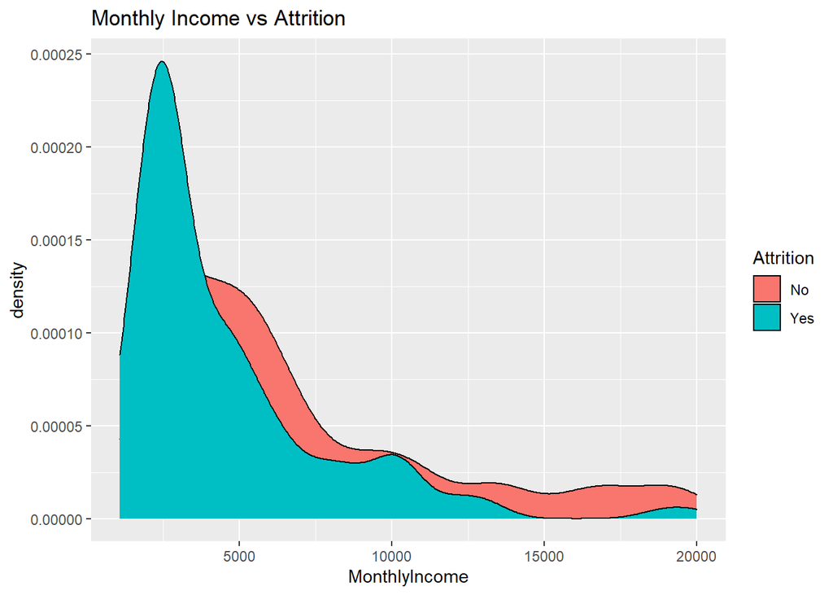

```r
#Monthly Income vs Attrition

ggplot(attdatalm,aes(x=MonthlyIncome,fill=Attrition))+geom_density()+ggtitle("Monthly Income vs Attrition")
```

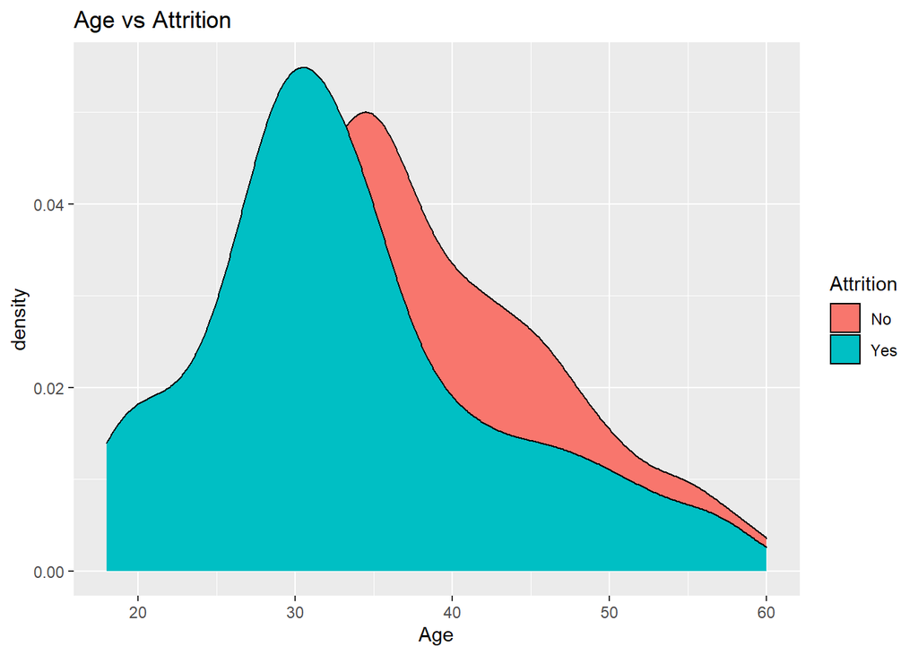

```r
#Age vs Attrition
ggplot(attdatalm,aes(x=Age,fill=Attrition))+geom_density()+ggtitle("Age vs Attrition")
```

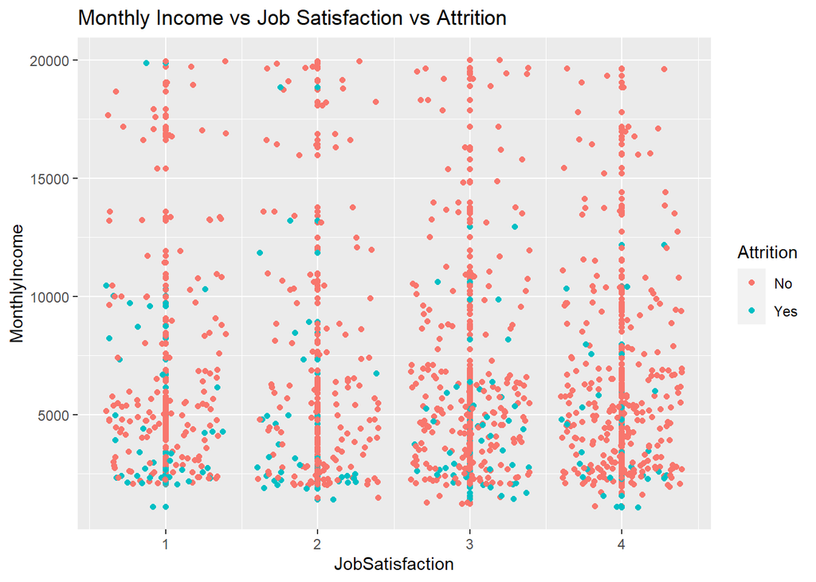

```r
#Monthly Income vs Job Satisfaction vs Attrition
ggplot(attdatalm,aes(y=MonthlyIncome,x=JobSatisfaction,color=Attrition))+geom_point()+geom_point(position="jitter")+ggtitle("Monthly Income vs Job Satisfaction vs Attrition")
```

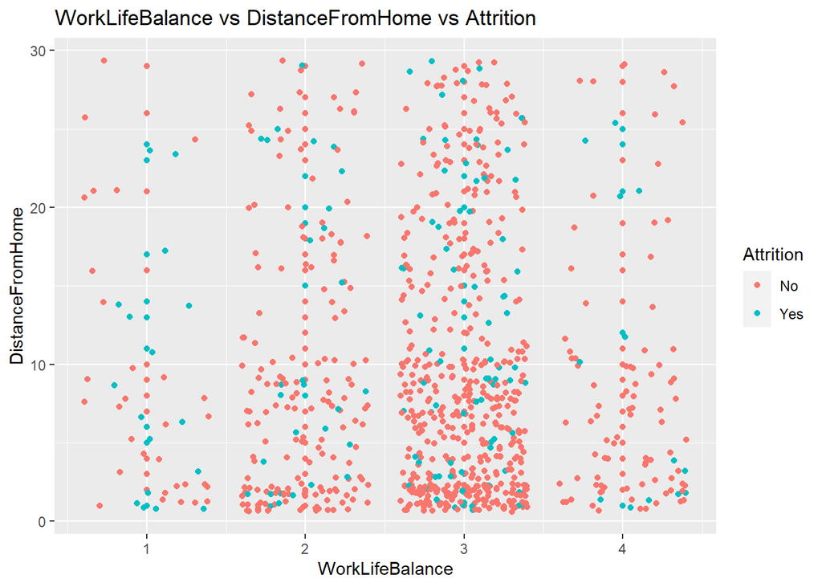

```r
ggplot(attdatalm,aes(x=WorkLifeBalance,y=DistanceFromHome,color=Attrition))+geom_point()+geom_point(position="jitter")+ggtitle("WorkLifeBalance vs DistanceFromHome vs Attrition")
```

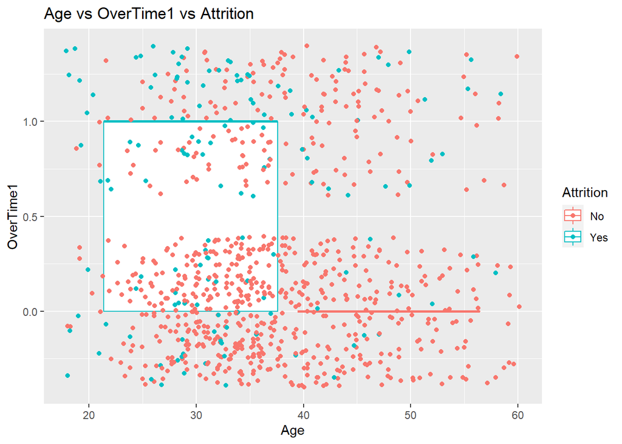

```r
ggplot(attdatalm,aes(x=Age,y=OverTime1,color=Attrition))+geom_boxplot()+geom_point(position="jitter")+ggtitle("Age vs OverTime1 vs Attrition")
```

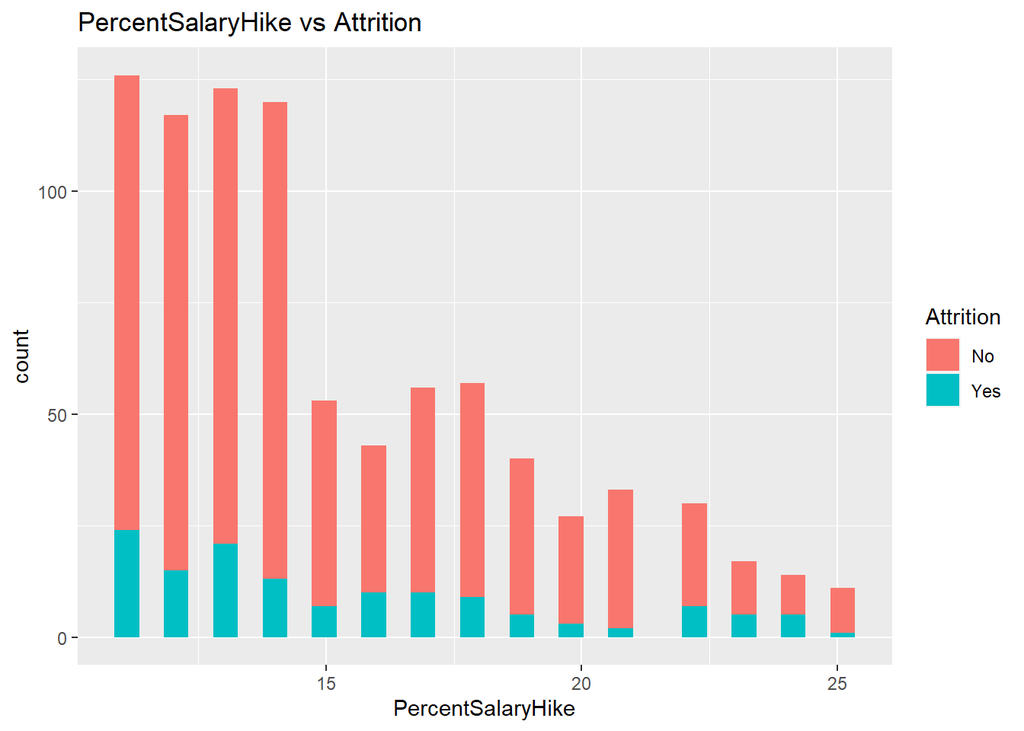

```r
ggplot(attdatalm,aes(x=PercentSalaryHike
,fill=Attrition))+geom_histogram()+ggtitle("PercentSalaryHike vs Attrition")
```

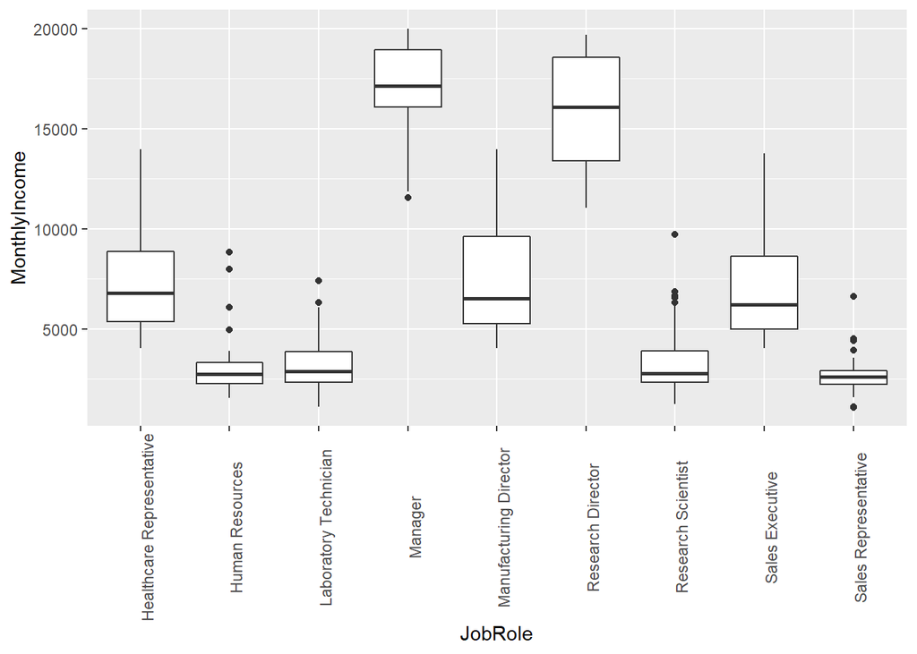

```r
attdatalm %>% ggplot(aes(x = JobRole, y = MonthlyIncome,)) + geom_boxplot() + theme(axis.text.x = element_text(angle = 90))
```

```r
attdata2<-attdatalm
```

## Prediction Modelling

Performing both KNN and NB method for prediction modelling and compare both for better specificty and sensitivity and accuracy. We will us ethe best model to redict Attrition and salary for the given separate data sets

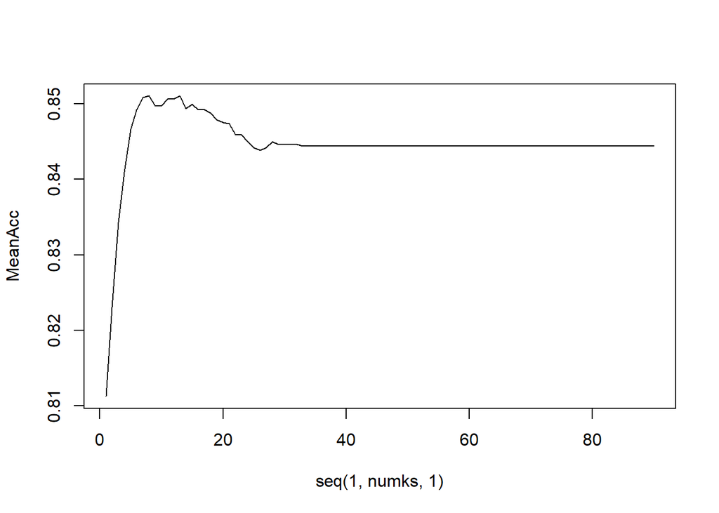

```r
#Finding k value by performing 25 iterations after splitting
##set.seed(3)
iterations = 25
numks = 90
splitPerc = .75

masterAcc = matrix(nrow = iterations, ncol = numks)

for(j in 1:iterations)
{
  trainattInd = sample(1:dim(attdata2)[1],round(splitPerc * dim(attdata2)[1]))
  train = attdata2[trainattInd,]
  test = attdata2[-trainattInd,]
  for(i in 1:numks)
  {
    classifications = knn(train[,c(2,43,44)],test[,c(2,43,44)],train$Attrition1, prob = TRUE, k = i)
    table(classifications,test$Attrition1)
    CM = confusionMatrix(table(classifications,test$Attrition1))
    masterAcc[j,i] = CM$overall[1]
  }

}

MeanAcc = colMeans(masterAcc)

plot(seq(1,numks,1),MeanAcc, type = "l")
```

```r
which.max(MeanAcc)
```

```
## [1] 8
```

```r
max(MeanAcc)
```

```
## [1] 0.8510599
```

```r
#KNN method

  trainattInd = sample(1:dim(attdata2)[1],round(splitPerc * dim(attdata2)[1]))
train = attdata2[trainattInd,]
  test = attdata2[-trainattInd,]
      classifications = knn(train[,c(2,5,12,14,15,18,20,21,22,25,26,27,29,30,31,32,33,34,35,36,43,44)],test[,c(2,5,12,14,15,18,20,21,22,25,26,27,29,30,31,32,33,34,35,36,43,44)],train$Attrition1,k=16)
      table(classifications,test$Attrition1)
```

```
##
## classifications   0   1
##               0 193  21
##               1   3   0
```

```r
    CM = confusionMatrix(table(classifications,test$Attrition1))


CM
```

```
## Confusion Matrix and Statistics
##
##
## classifications   0   1
##               0 193  21
##               1   3   0
##
##                Accuracy : 0.8894
##                  95% CI : (0.8399, 0.9278)
##     No Information Rate : 0.9032
##     P-Value [Acc > NIR] : 0.7924724
##
##                   Kappa : -0.0248
##
##  Mcnemar's Test P-Value : 0.0005202
##
##             Sensitivity : 0.9847
##             Specificity : 0.0000
##          Pos Pred Value : 0.9019
##          Neg Pred Value : 0.0000
##              Prevalence : 0.9032
##          Detection Rate : 0.8894
##    Detection Prevalence : 0.9862
##       Balanced Accuracy : 0.4923
##
##        'Positive' Class : 0
##
```

```r
#Naive Bayes method
modelnb = naiveBayes(train[,c(2,5,12,14,15,18,20,21,22,25,26,27,29,30,31,32,33,34,35,36,43,44)],as.factor(train$Attrition1))

dvv<-predict(modelnb,test[,c(2,5,12,14,15,18,20,21,22,25,26,27,29,30,31,32,33,34,35,36,43,44)])

table(predict(modelnb,test[,c(2,5,12,14,15,18,20,21,22,25,26,27,29,30,31,32,33,34,35,36,43,44)]),as.factor(test$Attrition1))
```

```
##
##       0   1
##   0 151   9
##   1  45  12
```

```r
CM = confusionMatrix(table(predict(modelnb,test[,c(2,5,12,14,15,18,20,21,22,25,26,27,29,30,31,32,33,34,35,36,43,44)]),as.factor(test$Attrition1)))

CM
```

```
## Confusion Matrix and Statistics
##
##
##       0   1
##   0 151   9
##   1  45  12
##
##                Accuracy : 0.7512
##                  95% CI : (0.6881, 0.8072)
##     No Information Rate : 0.9032
##     P-Value [Acc > NIR] : 1
##
##                   Kappa : 0.1936
##
##  Mcnemar's Test P-Value : 1.908e-06
##
##             Sensitivity : 0.7704
##             Specificity : 0.5714
##          Pos Pred Value : 0.9437
##          Neg Pred Value : 0.2105
##              Prevalence : 0.9032
##          Detection Rate : 0.6959
##    Detection Prevalence : 0.7373
##       Balanced Accuracy : 0.6709
##
##        'Positive' Class : 0
##
```

##Prediction of Attrition and monthly income for given data sets,First we will convert categorical variables to numberical similarly as above and perform NB classification technique and linear regression for predicting Attrition and Monthly income of given data sets

```r
attdata3<-attdata2
attdata3=subset(attdata3,select = -c(Attrition))


attpreddata=subset(AttritionPredData,select = -c(EmployeeCount,EmployeeNumber,Over18,StandardHours))
attpreddata<-AttritionPredData



#Changing variables to numeric for test Data set for predicting Attrition
##attpreddata$Attrition1[attpreddata$Attrition== "Yes"] <-1
##attpreddata$Attrition1[attpreddata$Attrition== "No"] <-0
attpreddata$BusinessTravel1[attpreddata$BusinessTravel== "Travel_Rarely"] <-2
attpreddata$BusinessTravel1[attpreddata$BusinessTravel== "Travel_Frequently"] <-3
attpreddata$Department1[attpreddata$Department== "Human Resources"] <-1
attpreddata$Department1[attpreddata$Department== "Research & Development"] <-2
attpreddata$Department1[attpreddata$Department== "Sales"] <-3
attpreddata$EducationField1[attpreddata$EducationField== "Human Resources"] <-1
attpreddata$EducationField1[attpreddata$EducationField== "Life Sciences"] <-2
attpreddata$EducationField1[attpreddata$EducationField== "Marketing"] <-3
attpreddata$EducationField1[attpreddata$EducationField== "Medical"] <-4
attpreddata$EducationField1[attpreddata$EducationField== "Other"] <-5
attpreddata$EducationField1[attpreddata$EducationField== "Technical Degree"] <-6
attpreddata$Gender1[attpreddata$Gender== "Female"] <-1
attpreddata$Gender1[attpreddata$Gender== "Male"] <-2
attpreddata$JobRole1[attpreddata$JobRole== "Human Resources"] <-1
attpreddata$JobRole1[attpreddata$JobRole== "Healthcare Representative"] <-2
attpreddata$JobRole1[attpreddata$JobRole== "Laboratory Technician"] <-3
attpreddata$JobRole1[attpreddata$JobRole== "Manager"] <-4
attpreddata$JobRole1[attpreddata$JobRole== "Manufacturing Director"] <-5
attpreddata$JobRole1[attpreddata$JobRole== "Research Director"] <-6
attpreddata$JobRole1[attpreddata$JobRole== "Research Scientist"] <-7
attpreddata$JobRole1[attpreddata$JobRole== "Sales Executive"] <-8
attpreddata$JobRole1[attpreddata$JobRole== "Sales Representative"] <-9
attpreddata$MaritalStatus1[attpreddata$MaritalStatus== "Divorced"] <-1
attpreddata$MaritalStatus1[attpreddata$MaritalStatus== "Married"] <-2
attpreddata$MaritalStatus1[attpreddata$MaritalStatus== "Single"] <-3
attpreddata$OverTime1[attpreddata$OverTime== "Yes"] <-1
attpreddata$OverTime1[attpreddata$OverTime== "No"] <-0



#Changing variables to numeric for test Data set for predicting MonthlyIncome

##AttritionSalaryData

attsaldata=subset(AttritionSalaryData,select = -c(EmployeeCount,EmployeeNumber,Over18,StandardHours))


attsaldata$Attrition1[attsaldata$Attrition== "Yes"] <-1
attsaldata$Attrition1[attsaldata$Attrition== "No"] <-0
attsaldata$BusinessTravel1[attsaldata$BusinessTravel== "Travel_Rarely"] <-2
attsaldata$BusinessTravel1[attsaldata$BusinessTravel== "Travel_Frequently"] <-3
attsaldata$Department1[attsaldata$Department== "Human Resources"] <-1
attsaldata$Department1[attsaldata$Department== "Research & Development"] <-2
attsaldata$Department1[attsaldata$Department== "Sales"] <-3
attsaldata$EducationField1[attsaldata$EducationField== "Human Resources"] <-1
attsaldata$EducationField1[attsaldata$EducationField== "Life Sciences"] <-2
attsaldata$EducationField1[attsaldata$EducationField== "Marketing"] <-3
attsaldata$EducationField1[attsaldata$EducationField== "Medical"] <-4
attsaldata$EducationField1[attsaldata$EducationField== "Other"] <-5
attsaldata$EducationField1[attsaldata$EducationField== "Technical Degree"] <-6
attsaldata$Gender1[attsaldata$Gender== "Female"] <-1
attsaldata$Gender1[attsaldata$Gender== "Male"] <-2
attsaldata$JobRole1[attsaldata$JobRole== "Human Resources"] <-1
attsaldata$JobRole1[attsaldata$JobRole== "Healthcare Representative"] <-2
attsaldata$JobRole1[attsaldata$JobRole== "Laboratory Technician"] <-3
attsaldata$JobRole1[attsaldata$JobRole== "Manager"] <-4
attsaldata$JobRole1[attsaldata$JobRole== "Manufacturing Director"] <-5
attsaldata$JobRole1[attsaldata$JobRole== "Research Director"] <-6
attsaldata$JobRole1[attsaldata$JobRole== "Research Scientist"] <-7
attsaldata$JobRole1[attsaldata$JobRole== "Sales Executive"] <-8
attsaldata$JobRole1[attsaldata$JobRole== "Sales Representative"] <-9
attsaldata$MaritalStatus1[attsaldata$MaritalStatus== "Divorced"] <-1
attsaldata$MaritalStatus1[attsaldata$MaritalStatus== "Married"] <-2
attsaldata$MaritalStatus1[attsaldata$MaritalStatus== "Single"] <-3
attsaldata$OverTime1[attsaldata$OverTime== "Yes"] <-1
attsaldata$OverTime1[attsaldata$OverTime== "No"] <-0

##attdata3=subset(attdata3,select = -c(Attrition))


# Prediction using NB method

modelnb = naiveBayes(attdata3[,c(2,4,11,13,14,17,19,20,21,24,25,26,28,29,30,31,32,33,34,35,42,43)],as.factor(attdata3$Attrition1))

summary(modelnb)
```

```
##           Length Class  Mode
## apriori    2     table  numeric
## tables    22     -none- list
## levels     2     -none- character
## isnumeric 22     -none- logical
## call       3     -none- call
```